**Transfer Learning**

By Prof. Seungchul Lee  
http://iai.postech.ac.kr/  
Industrial AI Lab at POSTECH

Table of Contents

# 1. Pre-trained Model (VGG16)

- Training a model on ImageNet from scratch takes days or weeks.
- Many models trained on ImageNet and their weights are publicly available!
- Transfer learning
  - Use pre-trained weights, remove last layers to compute representations of images
  - The network is used as a generic feature extractor
  - Train a classification model from these features on a new classification task
  - Pre- trained models can extract more general image features that can help identify edges, textures, shapes, and object composition
  - Better than handcrafted feature extraction on natural images

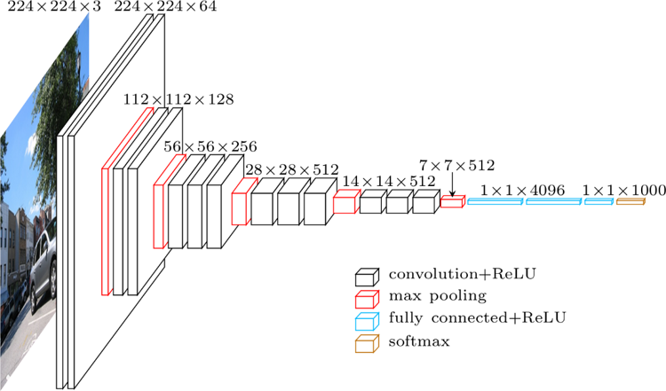

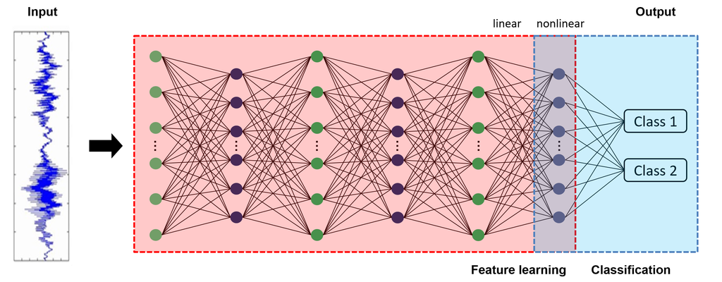

## 1.1. Import Library

```python
import numpy as np
import matplotlib.pyplot as plt

import tensorflow as tf
from keras.applications.vgg16 import VGG16
from keras.applications.vgg16 import decode_predictions
```

## 1.2. Load Data

Download data files from [here](https://www.dropbox.com/s/34hg800xhhvm80c/transfer_learning_lecture_data_files.zip?dl=1)

```python
train_imgs = np.load('./data_files/target_images.npy')
train_labels = np.load('./data_files/target_labels.npy')
test_imgs = np.load('./data_files/test_images.npy')
test_labels = np.load('./data_files/test_labels.npy')

print(train_imgs.shape)
print(train_labels[0]) # one-hot-encoded 5 classes
```

```
(65, 224, 224, 3)
[1. 0. 0. 0. 0.]
```

```python
Dict = ['Hat','Cube','Card','Torch','screw']
```

[figure not shown]

```python
n_train = train_imgs.shape[0]
n_test = test_imgs.shape[0]
idx = np.random.randint(n_train)

plt.figure(figsize = (6,6))
plt.imshow(train_imgs[idx])
plt.title("Label : {}".format(Dict[np.argmax(train_labels[idx])]))
plt.axis('off')
plt.show()
```

## 1.3. Load VGG16 Model

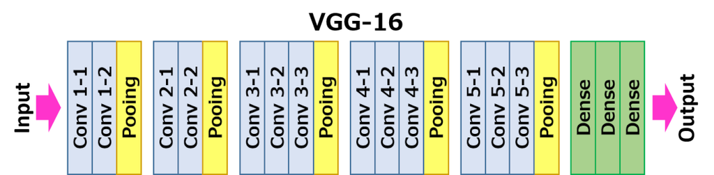

```python
model = VGG16(weights = 'imagenet')

model.summary()
```

```
_________________________________________________________________
Layer (type)                 Output Shape              Param #
=================================================================
input_1 (InputLayer)         (None, 224, 224, 3)       0
_________________________________________________________________
block1_conv1 (Conv2D)        (None, 224, 224, 64)      1792
_________________________________________________________________
block1_conv2 (Conv2D)        (None, 224, 224, 64)      36928
_________________________________________________________________
block1_pool (MaxPooling2D)   (None, 112, 112, 64)      0
_________________________________________________________________
block2_conv1 (Conv2D)        (None, 112, 112, 128)     73856
_________________________________________________________________
block2_conv2 (Conv2D)        (None, 112, 112, 128)     147584
_________________________________________________________________
block2_pool (MaxPooling2D)   (None, 56, 56, 128)       0
_________________________________________________________________
block3_conv1 (Conv2D)        (None, 56, 56, 256)       295168
_________________________________________________________________
block3_conv2 (Conv2D)        (None, 56, 56, 256)       590080
_________________________________________________________________
block3_conv3 (Conv2D)        (None, 56, 56, 256)       590080
_________________________________________________________________
block3_pool (MaxPooling2D)   (None, 28, 28, 256)       0
_________________________________________________________________
block4_conv1 (Conv2D)        (None, 28, 28, 512)       1180160
_________________________________________________________________
block4_conv2 (Conv2D)        (None, 28, 28, 512)       2359808
_________________________________________________________________
block4_conv3 (Conv2D)        (None, 28, 28, 512)       2359808
_________________________________________________________________
block4_pool (MaxPooling2D)   (None, 14, 14, 512)       0
_________________________________________________________________
block5_conv1 (Conv2D)        (None, 14, 14, 512)       2359808
_________________________________________________________________
block5_conv2 (Conv2D)        (None, 14, 14, 512)       2359808
_________________________________________________________________
block5_conv3 (Conv2D)        (None, 14, 14, 512)       2359808
_________________________________________________________________
block5_pool (MaxPooling2D)   (None, 7, 7, 512)         0
_________________________________________________________________
flatten (Flatten)            (None, 25088)             0
_________________________________________________________________
fc1 (Dense)                  (None, 4096)              102764544
_________________________________________________________________
fc2 (Dense)                  (None, 4096)              16781312
_________________________________________________________________
predictions (Dense)          (None, 1000)              4097000
=================================================================
Total params: 138,357,544
Trainable params: 138,357,544
Non-trainable params: 0
_________________________________________________________________
```

## 1.4. Testing for Target Data

```
1. mosquito_net: 4.66%
2. toilet_tissue: 4.00%
3. envelope: 2.29%
4. carton: 2.20%
5. photocopier: 1.86%
```

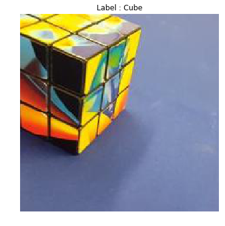

```python
idx = np.random.randint(n_train)
pred = model.predict(train_imgs[idx].reshape(-1, 224, 224, 3))

for (i, (_, label, prob)) in enumerate(decode_predictions(pred)[0]):
    print("{}. {}: {:.2f}%".format(i + 1, label, prob*100))

plt.figure(figsize = (6,6))
plt.imshow(train_imgs[idx])
plt.title("Label : {}".format(Dict[np.argmax(train_labels[idx])]))
plt.axis('off')
plt.show()
```

# 2. Transfer Learning

- We assume that these model parameters contain the knowledge learned from the source data set and that this knowledge will be equally applicable to the target data set.
- We will train the output layer from scratch, while the parameters of all remaining layers are fine tuned based on the parameters of the source model.
- Or initialize all weights from pre-trained model, then train them with target data

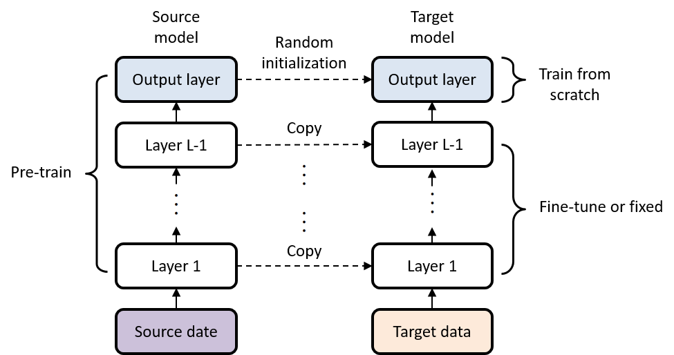

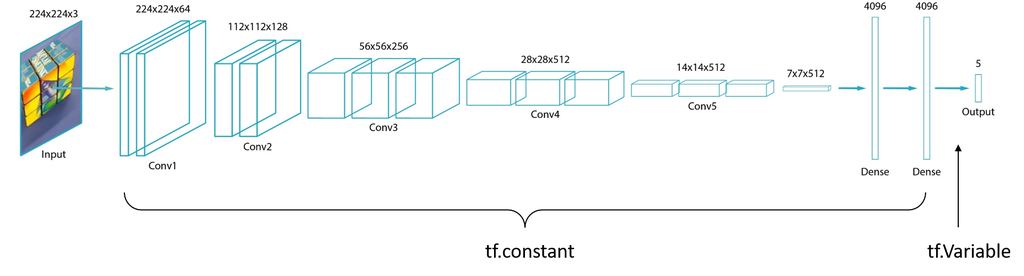

## 2.1. Pre-trained Weights, Biases

```python
vgg16_weights = model.get_weights()

weights = {
    'conv1_1' : tf.constant(vgg16_weights[0]),
    'conv1_2' : tf.constant(vgg16_weights[2]),

    'conv2_1' : tf.constant(vgg16_weights[4]),
    'conv2_2' : tf.constant(vgg16_weights[6]),

    'conv3_1' : tf.constant(vgg16_weights[8]),
    'conv3_2' : tf.constant(vgg16_weights[10]),
    'conv3_3' : tf.constant(vgg16_weights[12]),

    'conv4_1' : tf.constant(vgg16_weights[14]),
    'conv4_2' : tf.constant(vgg16_weights[16]),
    'conv4_3' : tf.constant(vgg16_weights[18]),

    'conv5_1' : tf.constant(vgg16_weights[20]),
    'conv5_2' : tf.constant(vgg16_weights[22]),
    'conv5_3' : tf.constant(vgg16_weights[24]),

    'fc1' : tf.constant(vgg16_weights[26]),
    'fc2' : tf.constant(vgg16_weights[28]),
    # train from scratch
    'out' : tf.Variable(tf.random_normal([4096, 5], stddev = 0.1))
}

biases = {
    'conv1_1' : tf.constant(vgg16_weights[1]),
    'conv1_2' : tf.constant(vgg16_weights[3]),

    'conv2_1' : tf.constant(vgg16_weights[5]),
    'conv2_2' : tf.constant(vgg16_weights[7]),

    'conv3_1' : tf.constant(vgg16_weights[9]),
    'conv3_2' : tf.constant(vgg16_weights[11]),
    'conv3_3' : tf.constant(vgg16_weights[13]),

    'conv4_1' : tf.constant(vgg16_weights[15]),
    'conv4_2' : tf.constant(vgg16_weights[17]),
    'conv4_3' : tf.constant(vgg16_weights[19]),

    'conv5_1' : tf.constant(vgg16_weights[21]),
    'conv5_2' : tf.constant(vgg16_weights[23]),
    'conv5_3' : tf.constant(vgg16_weights[25]),

    'fc1' : tf.constant(vgg16_weights[27]),
    'fc2' : tf.constant(vgg16_weights[29]),
    # train from scratch
    'out' : tf.Variable(tf.random_normal([5], stddev = 0.1))
}
```

```python
x = tf.placeholder(tf.float32, [None, 224, 224, 3])
y = tf.placeholder(tf.float32, [None, 5])
```

## 2.2. Build a Transfer Learning Model

```python
def transfer(x, weights, biases):
    # First convolution layer
    conv1_1 = tf.nn.conv2d(x,
                         weights['conv1_1'],
                         strides = [1, 1, 1, 1],
                         padding = 'SAME')
    conv1_1 = tf.nn.relu(tf.add(conv1_1, biases['conv1_1']))
    conv1_2 = tf.nn.conv2d(conv1_1,
                         weights['conv1_2'],
                         strides = [1, 1, 1, 1],
                         padding = 'SAME')
    conv1_2 = tf.nn.relu(tf.add(conv1_2, biases['conv1_2']))
    maxp1 = tf.nn.max_pool(conv1_2,
                           ksize = [1, 2, 2, 1],
                           strides = [1, 2, 2, 1],
                           padding = 'VALID')

    # Second convolution layer
    conv2_1 = tf.nn.conv2d(maxp1,
                         weights['conv2_1'],
                         strides = [1, 1, 1, 1],
                         padding = 'SAME')
    conv2_1 = tf.nn.relu(tf.add(conv2_1, biases['conv2_1']))
    conv2_2 = tf.nn.conv2d(conv2_1,
                         weights['conv2_2'],
                         strides = [1, 1, 1, 1],
                         padding = 'SAME')
    conv2_2= tf.nn.relu(tf.add(conv2_2, biases['conv2_2']))
    maxp2 = tf.nn.max_pool(conv2_2,
                           ksize = [1, 2, 2, 1],
                           strides = [1, 2, 2, 1],
                           padding = 'VALID')

    # third convolution layer
    conv3_1 = tf.nn.conv2d(maxp2,
                         weights['conv3_1'],
                         strides = [1, 1, 1, 1],
                         padding = 'SAME')
    conv3_1 = tf.nn.relu(tf.add(conv3_1, biases['conv3_1']))
    conv3_2 = tf.nn.conv2d(conv3_1,
                         weights['conv3_2'],
                         strides = [1, 1, 1, 1],
                         padding = 'SAME')
    conv3_2= tf.nn.relu(tf.add(conv3_2, biases['conv3_2']))
    conv3_3 = tf.nn.conv2d(conv3_2,
                         weights['conv3_3'],
                         strides = [1, 1, 1, 1],
                         padding = 'SAME')
    conv3_3= tf.nn.relu(tf.add(conv3_3, biases['conv3_3']))
    maxp3 = tf.nn.max_pool(conv3_3,
                           ksize = [1, 2, 2, 1],
                           strides = [1, 2, 2, 1],
                           padding = 'VALID')

    # fourth convolution layer
    conv4_1 = tf.nn.conv2d(maxp3,
                         weights['conv4_1'],
                         strides = [1, 1, 1, 1],
                         padding = 'SAME')
    conv4_1 = tf.nn.relu(tf.add(conv4_1, biases['conv4_1']))
    conv4_2 = tf.nn.conv2d(conv4_1,
                         weights['conv4_2'],
                         strides = [1, 1, 1, 1],
                         padding = 'SAME')
    conv4_2= tf.nn.relu(tf.add(conv4_2, biases['conv4_2']))
    conv4_3 = tf.nn.conv2d(conv4_2,
                         weights['conv4_3'],
                         strides = [1, 1, 1, 1],
                         padding = 'SAME')
    conv4_3= tf.nn.relu(tf.add(conv4_3, biases['conv4_3']))
    maxp4 = tf.nn.max_pool(conv4_3,
                           ksize = [1, 2, 2, 1],
                           strides = [1, 2, 2, 1],
                           padding = 'VALID')

    # fifth convolution layer
    conv5_1 = tf.nn.conv2d(maxp4,
                         weights['conv5_1'],
                         strides = [1, 1, 1, 1],
                         padding = 'SAME')
    conv5_1 = tf.nn.relu(tf.add(conv5_1, biases['conv5_1']))
    conv5_2 = tf.nn.conv2d(conv5_1,
                         weights['conv5_2'],
                         strides = [1, 1, 1, 1],
                         padding = 'SAME')
    conv5_2= tf.nn.relu(tf.add(conv5_2, biases['conv5_2']))
    conv5_3 = tf.nn.conv2d(conv5_2,
                         weights['conv5_3'],
                         strides = [1, 1, 1, 1],
                         padding = 'SAME')
    conv5_3= tf.nn.relu(tf.add(conv5_3, biases['conv5_3']))
    maxp5 = tf.nn.max_pool(conv5_3,
                           ksize = [1, 2, 2, 1],
                           strides = [1, 2, 2, 1],
                           padding = 'VALID')

    maxp5 = tf.reshape(maxp5, [-1, 7*7*512])

    # fully connected layer
    fc1 = tf.add(tf.matmul(maxp5, weights['fc1']), biases['fc1'])
    fc1 = tf.nn.relu(fc1)

    fc2 = tf.add(tf.matmul(fc1, weights['fc2']), biases['fc2'])
    fc2 = tf.nn.relu(fc2)

    # our output layer for a new classification task
    out = tf.add(tf.matmul(fc2, weights['out']), biases['out'])

    return out
```

## 2.3. Define Loss and Optimizer

```python
LR  = 0.001

pred = transfer(x, weights, biases)
loss = tf.nn.softmax_cross_entropy_with_logits(logits = pred, labels = y)
loss = tf.reduce_mean(loss)

optm  = tf.train.AdamOptimizer(LR).minimize(loss)
```

## 2.4. Optimize

```python
def train_batch_maker(batch_size):
    random_idx = np.random.randint(n_train, size = batch_size)
    return train_imgs[random_idx], train_labels[random_idx]
```

```python
def test_batch_maker(batch_size):
    random_idx = np.random.randint(n_test, size = batch_size)
    return test_imgs[random_idx], test_labels[random_idx]
```

```
Epoch : 0
Cost : 5.851983547210693
Epoch : 30
Cost : 0.9399541616439819
Epoch : 60
Cost : 0.42500433325767517
Epoch : 90
Cost : 0.2131207287311554
Epoch : 120
Cost : 0.17992165684700012
Epoch : 150
Cost : 0.17478522658348083
Epoch : 180
Cost : 0.10303795337677002
Epoch : 210
Cost : 0.15159498155117035
Epoch : 240
Cost : 0.10088126361370087
Epoch : 270
Cost : 0.0622907355427742
```

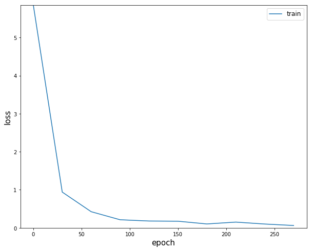

```python
n_batch = 20
n_epoch = 300
n_prt = 30

sess = tf.Session()
sess.run(tf.global_variables_initializer())

loss_record_train = []
for epoch in range(n_epoch):
    train_x, train_y = train_batch_maker(n_batch)
    sess.run(optm, feed_dict = {x: train_x, y: train_y})

    if epoch % n_prt == 0:
        c = sess.run(loss, feed_dict = {x: train_x, y: train_y})
        loss_record_train.append(c)
        print ("Epoch : {}".format(epoch))
        print ("Cost : {}".format(c))

plt.figure(figsize = (10,8))
plt.plot(np.arange(len(loss_record_train))*n_prt, loss_record_train, label = 'train')
plt.xlabel('epoch', fontsize = 15)
plt.ylabel('loss', fontsize = 15)
plt.legend(fontsize = 12)
plt.ylim([0, np.max(loss_record_train)])
plt.show()
```

## 2.5. Test and Evaluate

```python
my_pred = sess.run(pred, feed_dict = {x: test_imgs})
my_pred = np.argmax(my_pred, axis = 1)

labels = np.argmax(test_labels, axis = 1)

accr = np.mean(np.equal(my_pred, labels))
print("Accuracy : {}%".format(accr*100))
```

```
Accuracy : 100.0%
```

[figure not shown]

```
Prediction : Cube
Probability : [0.   0.99 0.01 0.   0.  ]
```

```python
test_x, test_y = test_batch_maker(1)
logits = sess.run(tf.nn.softmax(pred), feed_dict = {x: test_x.reshape(-1, 224, 224, 3)})
predict = np.argmax(logits)

plt.figure(figsize = (6,6))
plt.imshow(test_x.reshape(224, 224, 3))
plt.axis('off')
plt.show()

np.set_printoptions(precision = 2, suppress = True)
print('Prediction : {}'.format(Dict[predict]))
print('Probability : {}'.format(logits.ravel()))
```

```python
%%javascript
$.getScript('https://kmahelona.github.io/ipython_notebook_goodies/ipython_notebook_toc.js')
```